# Question

A quadratic polynomial, $f(x)$, is generated by randomly selecting two parameters, $B$ and $C$, in the equation below.

$$f(x)~=~x^2+Bx+C$$

Notice the leading coefficient (of the quadratic term) is 1. However the linear coefficient and the constant are randomly determined.

When $y=f(x)$ is graphed below, you notice it has zeros (roots, $x$-intercepts) at coordinates $(-6,0)$ and $(2,0)$.

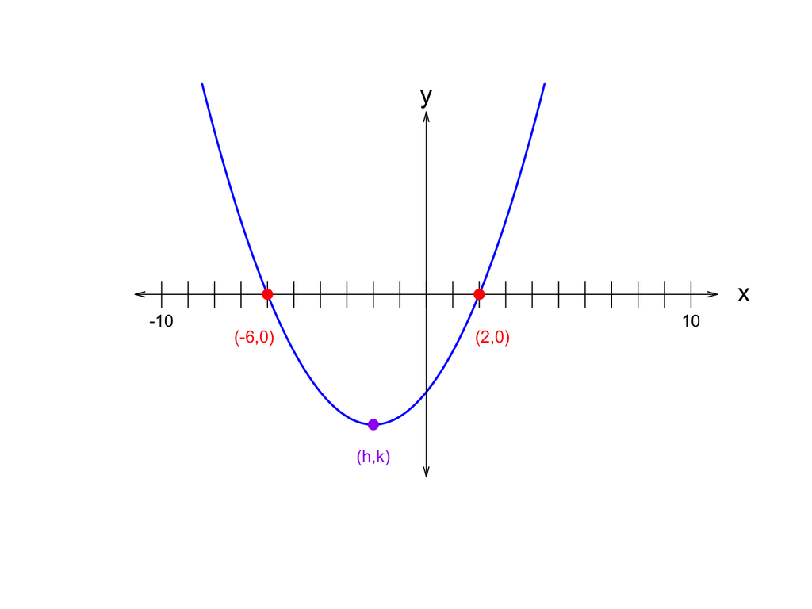

### Factored form

The polynomial $f(x)$ can be expressed in **factored form**. Which option correctly expresses $f(x)$ in factored form?

1. $f(x) = (x-{6})\cdot (x+{2})$
2. $f(x) = (x+{6})\cdot (x-{2})$
3. $f(x) = (x-{6})\cdot (x-{2})$
4. $f(x) = (x+{6})\cdot (x+{2})$

### Standard (expanded) form

The polynomial $f(x)$ can be expressed in **standard form**. Which option correctly expresses $f(x)$ in standard form?

7. $f(x) = x^{2}+{8}x+{12}$
8. $f(x) = x^{2}+{4}x-{12}$
9. $f(x) = x^{2}-{8}x+{12}$
10. $f(x) = x^{2}-{4}x-{12}$

### Vertex form

The polynomial $f(x)$ can be expressed in **vertex form**:

$$f(x)~=~ (x-h)^2+k$$

where coordinates $(h,k)$ are at the vertex of the parabola (as marked on the graph). Which option correctly expresses $f(x)$ in vertex form?

16. $f(x)~=~(x+4)^2-4$
17. $f(x)~=~(x-4)^2-4$
18. $f(x)~=~(x-2)^2-16$
19. $f(x)~=~(x+2)^2-16$

## Answerlist

- a
- b
- c
- d
- g
- h
- i
- j
- p
- q
- r
- s

# Solution

If the zeros are at $(p,0)$ and $(q,0)$, then the factored form will be: $f(x)~=~(x-p)\cdot(x-q)$. In our case, $p=-6$ and $q=2$, so in factored form:

$$f(x) = (x+{6})\cdot (x-{2})$$

To get the standard (expanded) form, we can multiply the two linear binomials (using the [FOIL method](https://en.wikipedia.org/wiki/FOIL_method) or box method).

| * | $x$ | $6$ |
| --- | --- | --- |
| $x$ | $x^2$ | ${6}x$ |
| $-2$ | ${-2}x$ | $-12$ |

$$f(x)~=~x^{2}-{2}x+{6}x-{12}$$

Combine like terms.

$$f(x)~=~x^{2}+{4}x-{12}$$

To get the vertex form, first average $p$ and $q$ to get $h$.

$$h~=~ \frac{{-6}+{2}}{2} ~=~
-2$$

Then, plug $x=-2$ into the factored form or the standard form to get $k$.

$$k~=~({-2}+{6})\cdot({-2}-{2}) ~=~
-16$$
$$k~=~(-2)^2+(4)(-2)+(-12) ~=~
-16$$

So,

$$f(x)~=~(x+2)^2-16$$

# Meta-information

extype: cloze exclozetype: schoice|schoice|schoice exsolution: 0100|0100|0001 exname: quadratic_from_zeros